# Tutorial - Mi primera vez con R

8/11/2019

## Primera vez usando el R y Rstudio

R es software libre y Rstudio tiene una versión gratuita.

La versión de R está disponible en www.cran.r-project.org, en versión de Windows o de Linux.

## Simular variables y graficar.

Simular una variable aleatoria y crear un histograma con ésta variable, se puede hacer según se muestra en las siguientes líneas en gris.

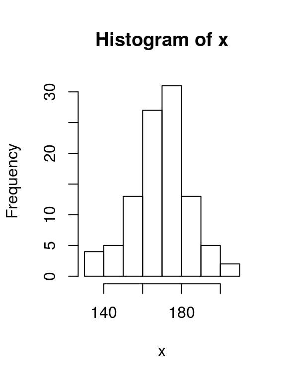

```r
x <- rnorm(n=100, mean=170, sd=15)
hist(x)
```

## Cambios en los parámetros

Simular una variable aleatoria y crear un histograma con ésta variable, se puede hacer según se muestra en las siguientes líneas en gris.

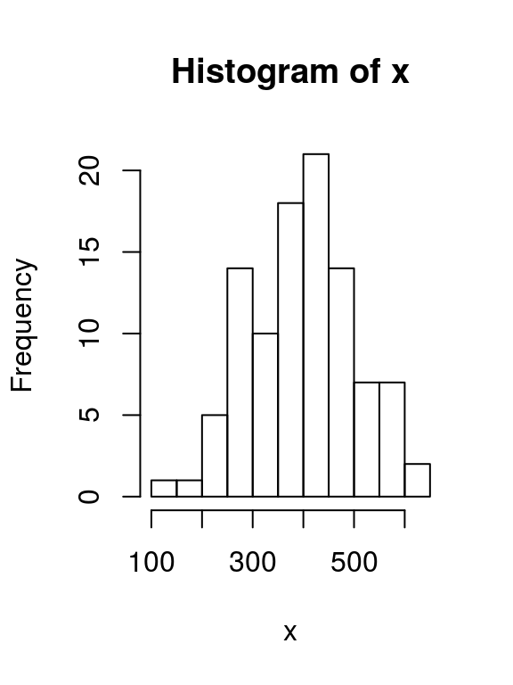

```r
x <- rnorm(n=100, mean=400, sd=100)
hist(x)
```

## Simular y realizar histograma

Variable aleatoria con distribución normal.

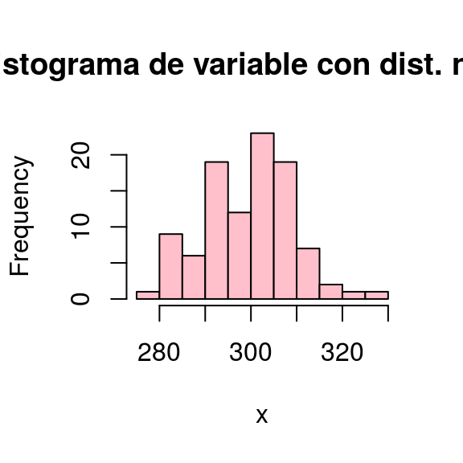

```r
x=rnorm(100,300,10)
hist(x,breaks=10,col='pink',main='Histograma de variable con dist. normal')
```

## Diagrama de cajas y bigotes.

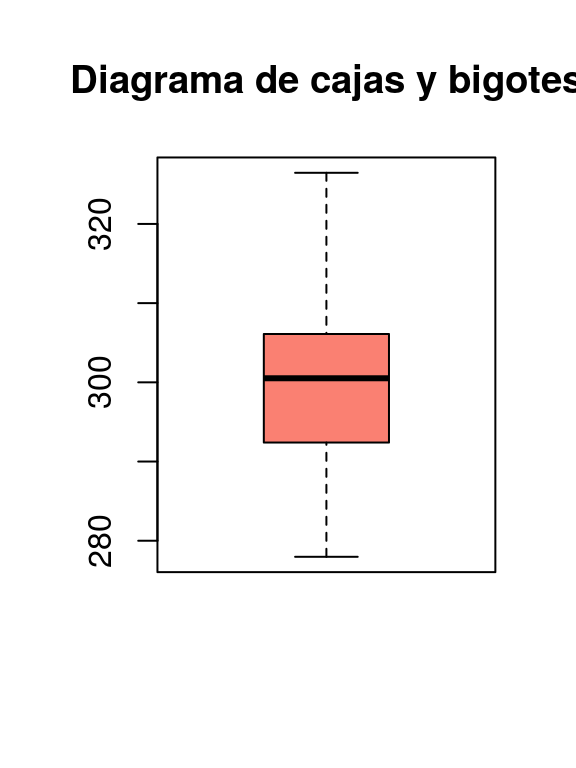

```r
boxplot(x,col='salmon',main='Diagrama de cajas y bigotes')
```

## Simular y realizar histograma de distribución Poisson.

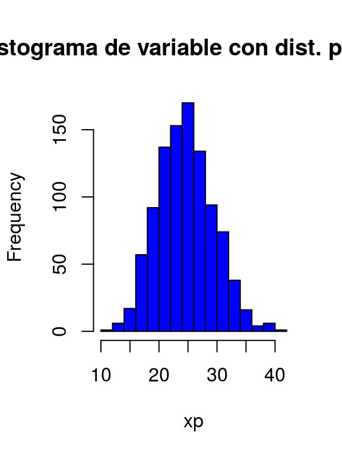

```r
xp=rpois(1000,25)
hist(xp,breaks=20,col='blue',main='Histograma de variable con dist. poisson')
```

## Diagrama de cajas y bigotes.

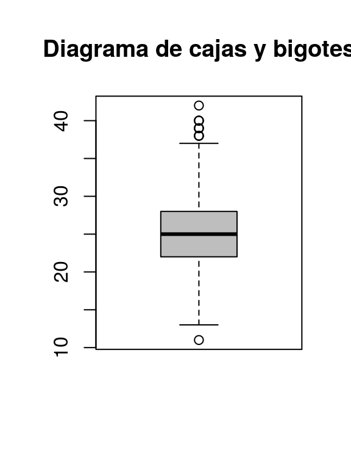

```r
boxplot(xp,col='grey',main='Diagrama de cajas y bigotes')
```

## Instalar un paquete para otros estadísticos.

```r
install.packages('sfsmisc')
library(sfsmisc)
```

## Histograma y diagrama de cajas y bigotes con el paquete sfsmisc

Variable con distribución T de Student.

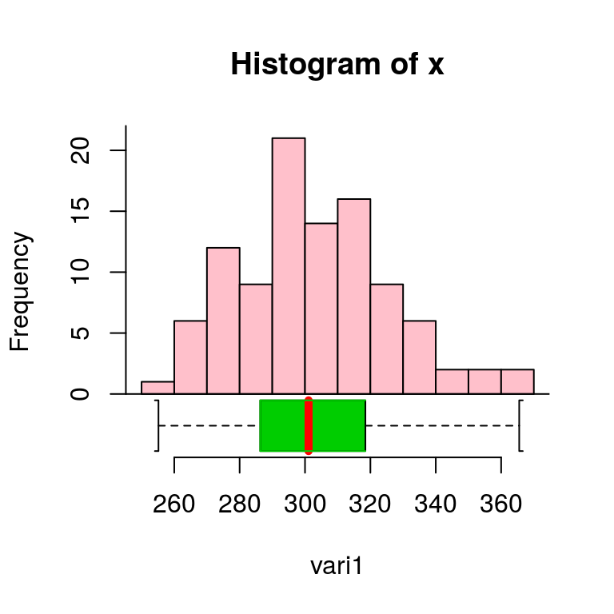

```r
vari1=rt(100,99,300)
histBxp(vari1,col='pink')
```

## Simulación de variable con distribución Poisson

Variable con distribución Poisson.

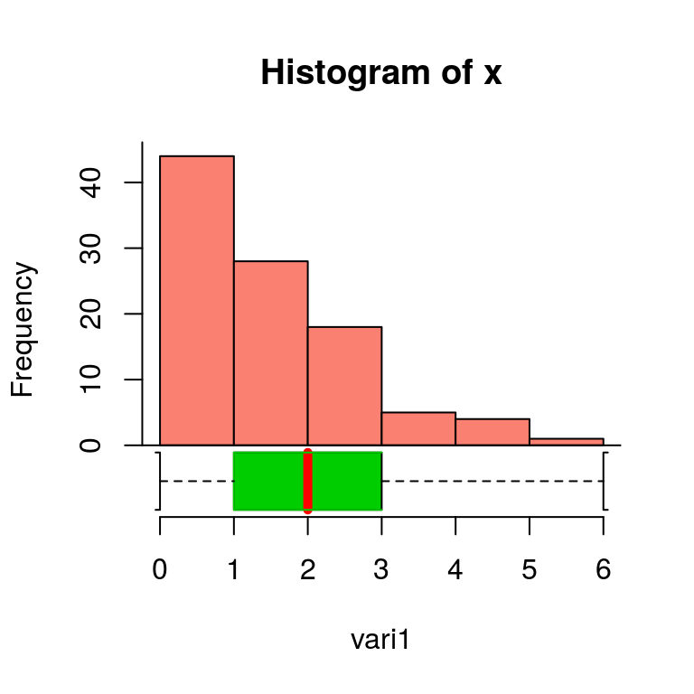

```r
vari1=rpois(100,2)
histBxp(vari1,col='salmon')
```

## Instalar un paquete para otras estadísticas.

El paquete fBAsics e útil para estiman diferentes estadísticas básicas de una variable aleatoria determinada.

```r
install.packages("fBasics")
library(fBasics)
```

## Resumen de estadísticas generales

```r
x1=rt(100,99,1)
summary(x1)
```

```
##    Min. 1st Qu.  Median    Mean 3rd Qu.    Max.
## -1.3010  0.4186  1.0631  0.9696  1.5091  3.6591
```

## Resumen de estadísticas generales con el paquete fBasics

La función basicStats estima diferentes estadísticas.

```r
vari1=rt(100, 99,300)
basicStats(vari1)
```

```
##                    vari1
## nobs          100.000000
## NAs             0.000000
## Minimum       255.792997
## Maximum       349.442557
## 1. Quartile   282.511429
## 3. Quartile   313.128450
## Mean          299.757259
## Median        300.642915
## Sum         29975.725903
## SE Mean         2.285199
## LCL Mean      295.222929
## UCL Mean      304.291589
## Variance      522.213280
## Stdev          22.851986
## Skewness        0.276443
## Kurtosis       -0.544934
```

## Resumen de estadísticas generales con el paquete fBasics

```r
library(knitr)
vari1=rpois(200,3)
kable(basicStats(vari1),digits=2)
```

|  | vari1 |
| --- | --- |
| nobs | 200.00 |
| NAs | 0.00 |
| Minimum | 0.00 |
| Maximum | 9.00 |
| 1. Quartile | 2.00 |
| 3. Quartile | 4.00 |
| Mean | 3.23 |
| Median | 3.00 |
| Sum | 647.00 |
| SE Mean | 0.13 |
| LCL Mean | 2.98 |
| UCL Mean | 3.49 |
| Variance | 3.45 |
| Stdev | 1.86 |
| Skewness | 0.55 |
| Kurtosis | 0.02 |

## Hacer pruebas de diferencia de medias

```r
x=rnorm(100,3,1)
y=rnorm(100,5,5)
t.test(x,y)
```

```
##
##  Welch Two Sample t-test
##
## data:  x and y
## t = -6.6904, df = 107.06, p-value = 1.05e-09
## alternative hypothesis: true difference in means is not equal to 0
## 95 percent confidence interval:
##  -4.500132 -2.442917
## sample estimates:
## mean of x mean of y
##  2.891614  6.363139
```

## Pruebas de normalidad

shapiro.test es una función para aplicar la prueba de Shapiro Wilks.

```r
x=rnorm(100,3,1)
shapiro.test(x)
```

```
##
##  Shapiro-Wilk normality test
##
## data:  x
## W = 0.9855, p-value = 0.3448
```

## Pruebas de normalidad del paquete fBasics

```r
x=rnorm(100,3,1)
normalTest(x,'sw')
```

```
##
## Title:
##  Shapiro - Wilk Normality Test
##
## Test Results:
##   STATISTIC:
##     W: 0.9929
##   P VALUE:
##     0.8846
##
## Description:
##  Wed Oct 30 14:55:02 2019 by user:
```

La función normalTest(x) de fBasics realiza cuatro pruebas de normalidad: Shapiro Wilks, Jarque Bera, Kolmogorov, D’Agostino.

## Otras pruebas de normalidad

```r
x=rpois(100,3)
normalTest(x,'jb')
```

```
##
## Title:
##  Jarque - Bera Normalality Test
##
## Test Results:
##   STATISTIC:
##     X-squared: 1.5338
##   P VALUE:
##     Asymptotic p Value: 0.4644
##
## Description:
##  Wed Oct 30 14:55:02 2019 by user:
```

## Prueba de bondad de ajuste Kolmogorov para Distribución Poisson

```r
x=rpois(50,10)
ks.test(x,'ppois',lambda=10)
```

```
##
##  One-sample Kolmogorov-Smirnov test
##
## data:  x
## D = 0.19156, p-value = 0.05098
## alternative hypothesis: two-sided
```

## Prueba de bondad de ajuste Chicuadrado

```r
x1=rpois(50,10)
x2=rpois(50,10)
chisq.test(x1,x2)
```

```
##
##  Pearson's Chi-squared test
##
## data:  x1 and x2
## X-squared = 150.56, df = 121, p-value = 0.03543
```

## Diagramas de barra

```r
require(lattice)
```

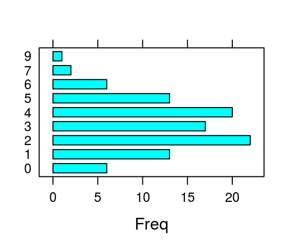

```r
fax=factor(rpois(100,3))
barchart(table(fax))
```

## Crear vectores de datos

```r
x1=c(1.2,4.1,4,15,12,16,16)
x2=c(0,1.1,2,13,12,15,12)
x1;x2
```

```
## [1]  1.2  4.1  4.0 15.0 12.0 16.0 16.0
```

```
## [1]  0.0  1.1  2.0 13.0 12.0 15.0 12.0
```

## Creación de matrices

```r
matri1=cbind(x1,x2)
matri1
```

```
##        x1   x2
## [1,]  1.2  0.0
## [2,]  4.1  1.1
## [3,]  4.0  2.0
## [4,] 15.0 13.0
## [5,] 12.0 12.0
## [6,] 16.0 15.0
## [7,] 16.0 12.0
```

## Estimar Covarianza y Correlación

```r
cov(x1,x2)
```

```
## [1] 40.9819
```

```r
cor(x1,x2)
```

```
## [1] 0.9790429
```

## Diagrama de dispersión

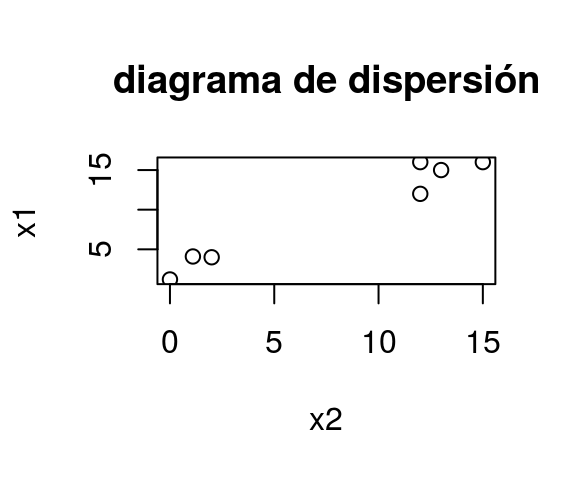

```r
plot(x1~x2,main='diagrama de dispersión')
```

## Simular regresión

```r
xt=rnorm(100,2,1)
y=2-1.9*xt+rnorm(100,0,1)
```

## Covarianza, Correlación y diagrama de dispersión de ‘y’ vs ‘xt’

```r
cov(xt,y)
```

```
## [1] -2.015272
```

```r
cor(xt,y)
```

```
## [1] -0.8786795
```

## Diagrama de dispersión de ‘y’ vs ‘xt’

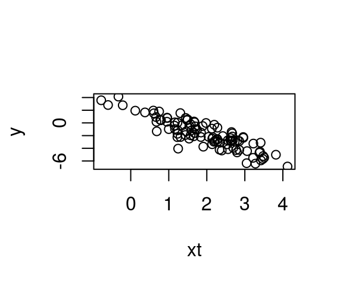

```r
plot(y~xt)
```

## Cargar una base de datos

Forma 1:

La instrucción para leer una base de datos en extensión csv es:

base1=read.csv(file.choose(),sep=‘;’,dec=‘,’,head=T)

Previamente se guarda el archivo separado por comas.

## Cargar una base de datos

Forma 2:

Si se tiene el archivo guardado con extensión en xlsx.

```r
library(readxl)
dataset1 <- read_excel(file.choose())
View(dataset1)
attach(dataset1)
```

## Cargar una base de datos

Forma 3:

Cargar la base desde la sección Enviroment, en Import Dataset.

Lectura de base de datos desde Enviroment.

[figure not shown]

Seguido a ésta, se usa la función attach para incorporar las variables independientes de la base de datos.

## Análisis de covarianza y correlación

```r
plot(totalservicios,totalapps)
cov(totalservicios,totalapps)
cor(totalservicios,totalapps)
```

Realizar ejercicio en el taller.

## Modelo de regresión lineal múltiple

```r
lcali=log(totalservicios)
modelo2=lm(lcali~género+ingresos+totalservicios-1)
summary(modelo2)
Anova(modelo2,type='III')
```

Realizar ejercicio en taller.

## Iniciando con Rmarkdowm

Para trabajar con R Markdown usted necesita: * Instalar R: [R](http://www.r-project.org/) * Instalar la última versión de Rstudio: [RStudio](http://rstudio.org/download/)

## Para trabajar con R Markdown usted necesita:

- Instalar R: [R](http://www.r-project.org/)
- Instalar la última versión de Rstudio: [RStudio](http://rstudio.org/download/)
- Instalar el paquete `knitr` : `install.packages("knitr")`

## Gracias

- Marisol Valencia Cárdenas
- Docente
- Fundación Universitaria Autónoma de las Américas
- marisol.valencia@uam.edu.co